# Sabatina,

## *assunto*: métodos baseados em árvores

> - [Emerson Rigoni](http://lattes.cnpq.br/9410653573760282)
> - Henrique Aparecido Laureano [[GitLab](https://gitlab.c3sl.ufpr.br/u/hal11), [GitHub](https://github.com/mynameislaure), [Lattes](http://lattes.cnpq.br/2224901552085090)]

### Junho de 2016

## Proposta

*Com as bases `Pima.tr` e `Pima.te` do package `MASS` encontrar as duas covariáveis que melhor classificam o resultado do teste de diabetes*

## Banco de dados

```r
library(MASS)

data("Pima.tr")
data("Pima.te")
```

*Uma população de mulheres (532) com no mínimo 21 anos, descendentes da tribo indígina Pima e atualmente vivendo próximo de Phoenix, Arizona, que fizeram o teste para diabetes de acordo o critério da Organização Mundial da Saúde (OMS)*

*Os dados foram coletados pelo Instituto Nacional Norte Americano de Diabetes e Doenças de Digestivas e Renais*

*No banco de dados de **treino** (`Pima.tr`) temos 200 indivíduos, e no banco de dados de **teste** (`Pima.te`) temos os demais 332 indivíduos*

- `npreg`: número de gestações

```r
summary(Pima.tr$npreg)
```

```
   Min. 1st Qu.  Median    Mean 3rd Qu.    Max.
   0.00    1.00    2.00    3.57    6.00   14.00
```

```r
summary(Pima.te$npreg)
```

```
   Min. 1st Qu.  Median    Mean 3rd Qu.    Max.
  0.000   1.000   2.000   3.485   5.000  17.000
```

- `glu`: concentração de glicose no plasma em um teste oral de tolerância à glicose

```r
summary(Pima.tr$glu)
```

```
   Min. 1st Qu.  Median    Mean 3rd Qu.    Max.
   56.0   100.0   120.5   124.0   144.0   199.0
```

```r
summary(Pima.te$glu)
```

```
   Min. 1st Qu.  Median    Mean 3rd Qu.    Max.
   65.0    96.0   112.0   119.3   136.2   197.0
```

- `bp`: pressão sanguínea diastólica (mm Hg)

```r
summary(Pima.tr$bp)
```

```
   Min. 1st Qu.  Median    Mean 3rd Qu.    Max.
  38.00   64.00   70.00   71.26   78.00  110.00
```

```r
summary(Pima.te$bp)
```

```
   Min. 1st Qu.  Median    Mean 3rd Qu.    Max.
  24.00   64.00   72.00   71.65   80.00  110.00
```

- `skin`: espessura da prega cutânea no tríceps (mm)

```r
summary(Pima.tr$skin)
```

```
   Min. 1st Qu.  Median    Mean 3rd Qu.    Max.
   7.00   20.75   29.00   29.22   36.00   99.00
```

```r
summary(Pima.te$skin)
```

```
   Min. 1st Qu.  Median    Mean 3rd Qu.    Max.
   7.00   22.00   29.00   29.16   36.00   63.00
```

- `bmi`: índice de massa corporal ($peso (kg) / altura (m)^{2}$)

```r
summary(Pima.tr$bmi)
```

```
   Min. 1st Qu.  Median    Mean 3rd Qu.    Max.
  18.20   27.58   32.80   32.31   36.50   47.90
```

```r
summary(Pima.te$bmi)
```

```
   Min. 1st Qu.  Median    Mean 3rd Qu.    Max.
  19.40   28.17   32.90   33.24   37.20   67.10
```

- `ped`: função de diabetes pedigree

```r
summary(Pima.tr$ped)
```

```
   Min. 1st Qu.  Median    Mean 3rd Qu.    Max.
 0.0850  0.2535  0.3725  0.4608  0.6160  2.2880
```

```r
summary(Pima.te$ped)
```

```
   Min. 1st Qu.  Median    Mean 3rd Qu.    Max.
 0.0850  0.2660  0.4400  0.5284  0.6792  2.4200
```

- `age`: idade, em anos

```r
summary(Pima.tr$age)
```

```
   Min. 1st Qu.  Median    Mean 3rd Qu.    Max.
  21.00   23.00   28.00   32.11   39.25   63.00
```

```r
summary(Pima.te$age)
```

```
   Min. 1st Qu.  Median    Mean 3rd Qu.    Max.
  21.00   23.00   27.00   31.32   37.00   81.00
```

- `type`: `Yes` ou `No` para diabetes de acordo com o critério da OMS

```r
summary(Pima.tr$type)
```

```
 No Yes
132  68
```

```r
summary(Pima.te$type)
```

```
 No Yes
223 109
```

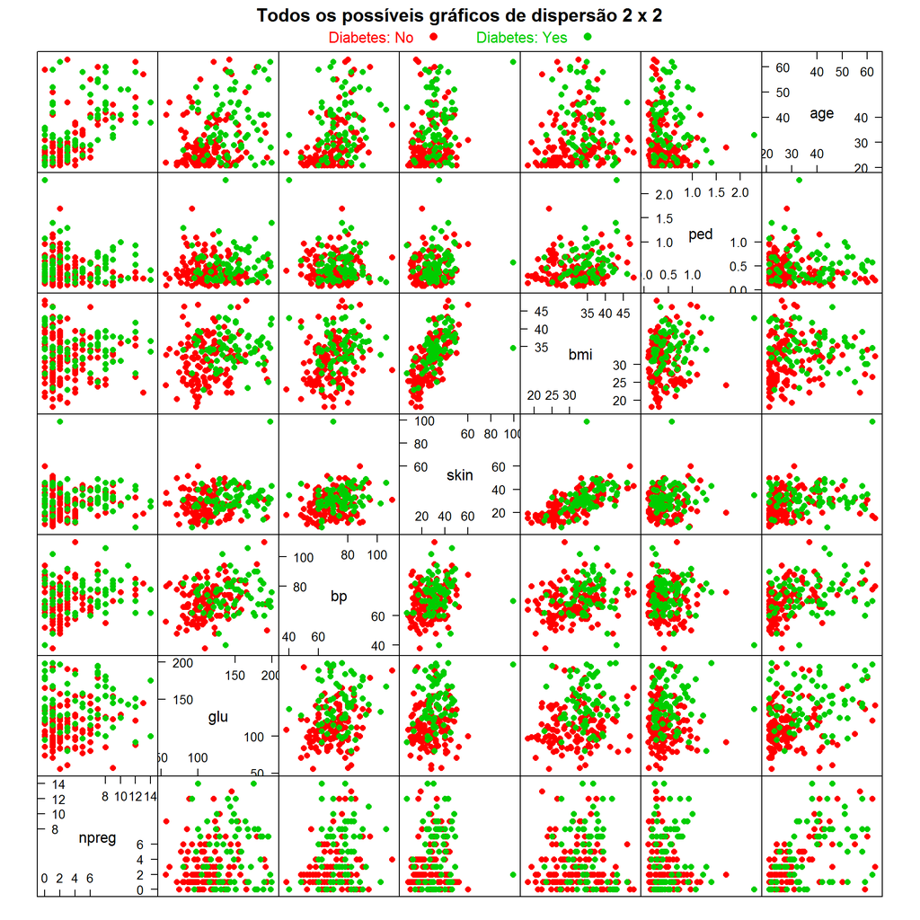

```r
library(latticeExtra)

splom(Pima.tr[1:7]
      , groups = Pima.tr$type
      , col = 2:3
      , xlab = NULL
      , pch = 16
      , main = "Todos os possíveis gráficos de dispersão 2 x 2"
      , key = list(text = list(c("Diabetes: No", "Diabetes: Yes"))
                   , columns = 2
                   , points = TRUE
                   , pch = 16
                   , col = 2:3))
```

## Random Forest

```r
library(randomForest)
```

### Base de treino

```r
(model <- randomForest(type ~ .
                       , Pima.tr
                       , importance = TRUE
                       , proximity = TRUE))
```

```
Call:
 randomForest(formula = type ~ ., data = Pima.tr, importance = TRUE,      proximity = TRUE)
               Type of random forest: classification
                     Number of trees: 500
No. of variables tried at each split: 2

        OOB estimate of  error rate: 27.5%
Confusion matrix:
     No Yes class.error
No  109  23   0.1742424
Yes  32  36   0.4705882
```

O modelo não está classificando muito bem na presença de todas as covariáveis, principalmente no caso das mulheres com resultado positivo

```r
importance(model)
```

```
             No        Yes MeanDecreaseAccuracy MeanDecreaseGini
npreg 10.761937  0.5162421            9.5597559         9.597752
glu   13.539915 15.3655683           19.2431944        22.392191
bp     6.123816 -6.8096005            0.3600998         7.962252
skin   1.179178  0.3921454            1.0915255         9.067550
bmi    3.923649  9.0491615            8.1178770        12.840096
ped    5.910101  4.7350967            7.3427757        13.588339
age   12.540266  4.7876090           13.0215618        13.986320
```

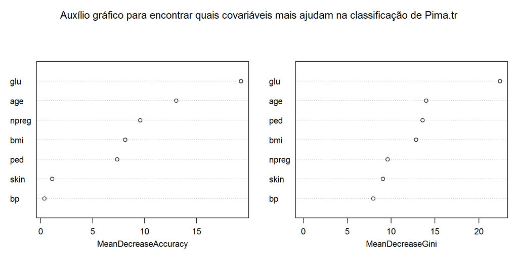

```r
varImpPlot(model
           , main = "Auxílio gráfico para encontrar quais covariáveis mais ajudam na classificação de Pima.tr")
```

As duas covariáveis que melhor classificam são: `glu` e `age`

```r
(model <- randomForest(type ~ glu + age
                       , Pima.tr
                       , importance = TRUE
                       , proximity = TRUE))
```

```
Call:
 randomForest(formula = type ~ glu + age, data = Pima.tr, importance = TRUE,      proximity = TRUE)
               Type of random forest: classification
                     Number of trees: 500
No. of variables tried at each split: 1

        OOB estimate of  error rate: 31.5%
Confusion matrix:
     No Yes class.error
No  100  32   0.2424242
Yes  31  37   0.4558824
```

### Base de teste

```r
modelpred <- predict(model, Pima.te)

(pred <- table(Pima.te$type, modelpred, dnn = list("Observado", "Predito")))
```

```
         Predito
Observado  No Yes
      No  193  30
      Yes  46  63
```

```r
# erro de classificação

## No
pred[1, 2] / sum(pred[1, ])
```

```
[1] 0.1345291
```

```r
## Yes
pred[2, 1] / sum(pred[2, ])
```

```
[1] 0.4220183
```

Em `Pima.te` temos erros de classificação consideravelmente grandes, principalmente nas mulheres com resultado positivo para diabetes

## Conclusão e considerações

*Tanto na figura abaixo com apenas as variáveis que ficaram na floresta aleatória definitiva, quanto no gráfico de dispersão 2 x 2 de todas as variáveis apresentado na seção ‘Banco de dados’, observa-se uma grande dificuldade de classificar o resultado do teste de diabetes das mulheres com bases nas variáveis. Nenhum padrão é observado*

*Um ponto positivo observado no resultado da floresta aleatória é que sua classificação não é feita com base em um ponto de corte que visualmente pode ser delimitado, ela lida melhor com problemas que não tem essa clara divisão, como é o caso do banco de dados aqui estudado. Contudo, aqui ela não apresentou bons resultados, dado a complexidade da classificação desejada*

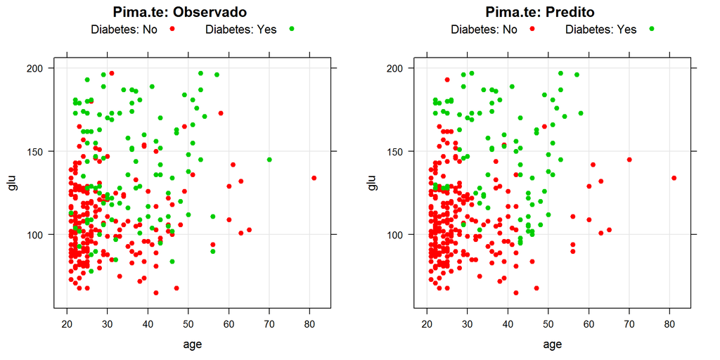

```r
print(xyplot(glu ~ age
             , groups = type
             , col = 2:3
             , pch = 19
             , type = c("p", "g")
             , main = "Pima.te: Observado"
             , key = list(space = "top"
                          , text = list(c("Diabetes: No", "Diabetes: Yes"))
                          , points = list(col = 2:3, pch = 19, cex = .8)
                          , columns = 2)
             , Pima.te)
      , position = c(0, 0, .5, 1), more = TRUE)

print(xyplot(glu ~ age
             , groups = modelpred
             , col = 2:3
             , pch = 19
             , type = c("p", "g")
             , main = "Pima.te: Predito"
             , key = list(space = "top"
                          , text = list(c("Diabetes: No", "Diabetes: Yes"))
                          , points = list(col = 2:3, pch = 19, cex = .8)
                          , columns = 2)
             , Pima.te)
      , position = c(.5, 0, 1, 1))
```